# 02_Exploratory_Data_Analysis

2024-09-10

# 1 Exploratory Data Analysis (EDA)

This document presents an exploratory data analysis of critical elements concentration data, which provide information about the concentration of critical mineral across different areas in Australia that has been normalised using PAAS (Post-Archean Australian Shale) standard. The primary objective of this analysis is to gain a deeper understanding of the data’s structure and key characteristics. Through this, we aim to identify significant trends, correlations, and outliers that may influence the outcomes of the study.

## 1.1 Data General Characteristics

Our data comprises of **11032 observations** and **8 variables**. Most of the variables are character type, except for variable `Element_Value_ppm`, `PAAS_value_ppm`, and `PAAS_normalised_value` that are numeric type.

```
## Classes 'data.table' and 'data.frame':   11032 obs. of  8 variables:
##  $ Project_Name         : chr  "Collingwood Park" "Confidential_B" "Confidential_B" "Confidential_B" ...
##  $ Sample_ID            : chr  "CP-014" "ICP23000472Z291" "ICP23000472Z292" "ICP23000472Z293" ...
##  $ Element_Symbol       : chr  "Ag" "Ag" "Ag" "Ag" ...
##  $ Element_Value_ppm    : num  0.13 0.14 0.11 0.11 0.11 0.11 0.11 0.11 0.15 0.5 ...
##  $ Element_Description  : chr  "Silver" "Silver" "Silver" "Silver" ...
##  $ PAAS_value_ppm       : num  0.05 0.05 0.05 0.05 0.05 0.05 0.05 0.05 0.05 0.05 ...
##  $ PAAS_normalised_value: num  2.6 2.8 2.2 2.2 2.2 2.2 2.2 2.2 3 10 ...
##  $ Above_PASS_flag      : chr  "Enriched above background" "Enriched above background" "Enriched above background" "Enriched above background" ...
##  - attr(*, ".internal.selfref")=<externalptr>
```

The **Table 1.1** provide a preview of the data from the first ten observations.

Table 1.1: The first ten observations of the data

| Project Name | Sample ID | Element Symbol | Element Value ppm | Element Description | PAAS value ppm | PAAS normalised value | Above PASS flag |
| --- | --- | --- | --- | --- | --- | --- | --- |
| Collingwood Park | CP-014 | Ag | 0.13 | Silver | 0.05 | 2.6 | Enriched above background |
| Confidential_B | ICP23000472Z291 | Ag | 0.14 | Silver | 0.05 | 2.8 | Enriched above background |
| Confidential_B | ICP23000472Z292 | Ag | 0.11 | Silver | 0.05 | 2.2 | Enriched above background |
| Confidential_B | ICP23000472Z293 | Ag | 0.11 | Silver | 0.05 | 2.2 | Enriched above background |
| Confidential_B | ICP23000472Z294 | Ag | 0.11 | Silver | 0.05 | 2.2 | Enriched above background |
| Confidential_B | ICP23000472Z299 | Ag | 0.11 | Silver | 0.05 | 2.2 | Enriched above background |
| Confidential_B | ICP23000472Z300 | Ag | 0.11 | Silver | 0.05 | 2.2 | Enriched above background |
| Confidential_B | ICP23000472Z301 | Ag | 0.11 | Silver | 0.05 | 2.2 | Enriched above background |
| Confidential_B | ICP23000472Z302 | Ag | 0.15 | Silver | 0.05 | 3.0 | Enriched above background |
| Confidential_C | IP23005174R1046 | Ag | 0.50 | Silver | 0.05 | 10.0 | Enriched above background |

## 1.2 Descriptive Statistics

In this section, we will provide some generic statistics information about the data, such as min, max, mean, median, and others. The **Table 1.2** lay out the details about these informations for each critical element that is included in the data.

Table 1.2: Descriptive Statistics of Elements’ Normalised Value

| Element Symbol | Element Description | min | max | mean | median | range | q1 | q3 | iqr | sd | var | skewness | kurtosis |
| --- | --- | --- | --- | --- | --- | --- | --- | --- | --- | --- | --- | --- | --- |
| Ag | Silver | 2.000 | 13.200 | 4.142 | 3.600 | 11.200 | 2.200 | 5.450 | 3.250 | 2.389 | 5.709 | 1.647 | 5.783 |
| Al | Aluminium | 0.000 | 8.500 | 0.845 | 0.438 | 8.500 | 0.212 | 1.288 | 1.075 | 0.982 | 0.965 | 4.403 | 34.192 |
| Au | Gold | 0.556 | 12.222 | 3.521 | 3.333 | 11.667 | 2.222 | 4.444 | 2.222 | 2.064 | 4.261 | 1.806 | 7.764 |
| Ba | Barium | 0.013 | 18.182 | 1.108 | 0.750 | 18.169 | 0.345 | 1.188 | 0.843 | 2.027 | 4.109 | 5.997 | 43.446 |
| Be | Beryllium | 0.033 | 6.000 | 1.126 | 0.667 | 5.967 | 0.333 | 1.333 | 1.000 | 1.134 | 1.285 | 1.981 | 7.156 |
| Bi | Bismuth | 0.787 | 25.197 | 3.685 | 2.402 | 24.409 | 1.575 | 4.724 | 3.150 | 3.302 | 10.904 | 3.012 | 17.818 |
| Cd | Cadmium | 0.102 | 7.347 | 1.271 | 0.918 | 7.245 | 0.510 | 1.888 | 1.378 | 1.115 | 1.243 | 2.075 | 9.839 |
| Ce | Cerium | 0.056 | 5.938 | 0.956 | 0.985 | 5.881 | 0.486 | 1.271 | 0.785 | 0.595 | 0.354 | 2.362 | 21.060 |
| Co | Cobalt | 0.118 | 7.882 | 0.906 | 0.588 | 7.765 | 0.353 | 0.897 | 0.544 | 1.133 | 1.285 | 3.617 | 17.661 |
| Cr | Chromium | 0.012 | 10.807 | 0.441 | 0.205 | 10.795 | 0.133 | 0.349 | 0.217 | 1.048 | 1.097 | 6.622 | 54.642 |
| Cs | Caesium | 0.024 | 6.870 | 1.068 | 0.923 | 6.846 | 0.532 | 1.382 | 0.851 | 0.910 | 0.829 | 2.460 | 12.858 |
| Cu | Copper | 0.040 | 10.200 | 1.681 | 1.880 | 10.160 | 0.640 | 2.430 | 1.790 | 1.160 | 1.345 | 1.617 | 13.140 |
| Dy | Dysprosium | 0.114 | 5.286 | 1.522 | 1.517 | 5.171 | 1.000 | 1.919 | 0.919 | 0.847 | 0.718 | 1.115 | 5.566 |
| Er | Erbium | 0.087 | 4.957 | 1.401 | 1.320 | 4.870 | 0.870 | 1.771 | 0.901 | 0.815 | 0.665 | 1.300 | 6.383 |
| Eu | Europium | 0.114 | 7.773 | 1.676 | 1.648 | 7.659 | 0.909 | 2.182 | 1.273 | 0.969 | 0.938 | 1.295 | 8.535 |
| Fe | Iron | 0.000 | 9.689 | 0.474 | 0.180 | 9.689 | 0.057 | 0.429 | 0.371 | 1.066 | 1.137 | 5.788 | 45.053 |
| Ga | Gallium | 0.076 | 3.076 | 1.293 | 1.291 | 3.000 | 0.759 | 1.860 | 1.101 | 0.684 | 0.467 | -0.020 | 2.148 |
| Gd | Gadolinium | 0.132 | 6.605 | 1.589 | 1.513 | 6.474 | 0.947 | 1.988 | 1.041 | 0.901 | 0.812 | 1.380 | 7.420 |
| Ge | Germanium | 0.088 | 43.750 | 7.481 | 0.344 | 43.663 | 0.183 | 9.500 | 9.317 | 13.031 | 169.804 | 1.458 | 3.653 |
| HREE | Ho+Er+Tm+Yb+Lu | 0.036 | 0.995 | 0.282 | 0.267 | 0.960 | 0.178 | 0.350 | 0.172 | 0.157 | 0.025 | 1.374 | 6.712 |
| Ho | Holmium | 0.125 | 4.750 | 1.352 | 1.306 | 4.625 | 0.875 | 1.694 | 0.819 | 0.767 | 0.588 | 1.187 | 5.962 |
| In | Indium | 0.400 | 7.200 | 1.434 | 1.000 | 6.800 | 0.600 | 2.000 | 1.400 | 1.117 | 1.247 | 2.167 | 9.581 |
| LREE | La+Ce+Pr+Nd+Pm+Sm | 0.089 | 4.214 | 1.020 | 1.064 | 4.125 | 0.616 | 1.370 | 0.754 | 0.540 | 0.292 | 0.837 | 6.992 |
| La | Lanthanum | 0.100 | 2.540 | 0.871 | 0.930 | 2.440 | 0.400 | 1.200 | 0.800 | 0.480 | 0.231 | 0.155 | 2.566 |
| Li | Lithium | 0.250 | 14.250 | 2.386 | 2.000 | 14.000 | 0.750 | 3.225 | 2.475 | 1.974 | 3.898 | 1.860 | 9.533 |
| Lu | Lutetium | 0.000 | 6.250 | 1.540 | 1.438 | 6.250 | 0.938 | 1.906 | 0.969 | 0.919 | 0.845 | 1.420 | 7.067 |
| MREE | Eu+Gd+Tb+Dy+Y | 0.088 | 4.384 | 1.361 | 1.344 | 4.296 | 0.801 | 1.698 | 0.896 | 0.756 | 0.571 | 1.200 | 5.952 |
| Mn | Manganese | 0.002 | 18.717 | 0.594 | 0.109 | 18.715 | 0.032 | 0.368 | 0.336 | 1.884 | 3.548 | 7.302 | 66.528 |
| Mo | Molybdenum | 0.067 | 13.733 | 2.971 | 2.667 | 13.667 | 1.333 | 3.333 | 2.000 | 2.195 | 4.816 | 2.227 | 10.237 |
| Nb | Niobium | 0.042 | 3.567 | 0.622 | 0.647 | 3.525 | 0.364 | 0.785 | 0.421 | 0.402 | 0.162 | 2.399 | 16.601 |
| Nd | Neodynium | 0.065 | 4.423 | 1.145 | 1.221 | 4.358 | 0.567 | 1.520 | 0.953 | 0.645 | 0.415 | 0.622 | 4.693 |
| Ni | Nickel | 0.023 | 8.182 | 0.386 | 0.159 | 8.159 | 0.114 | 0.295 | 0.182 | 0.869 | 0.756 | 5.983 | 44.099 |
| Pb | Lead | 0.052 | 4.909 | 1.276 | 1.235 | 4.856 | 0.651 | 1.647 | 0.996 | 0.856 | 0.732 | 1.344 | 6.139 |
| Pr | Praseodymi | 0.056 | 4.704 | 1.033 | 1.092 | 4.648 | 0.493 | 1.387 | 0.894 | 0.596 | 0.356 | 0.953 | 7.452 |
| REE | La+Ce+Pr+Nd+Sm+Eu+Gd+Tb+Dy+Ho+Er+Tm+Yb+Lu | 0.134 | 4.174 | 1.089 | 1.130 | 4.040 | 0.732 | 1.404 | 0.672 | 0.539 | 0.291 | 0.832 | 6.574 |
| REEY | La+Ce+Pr+Nd+Sm+Eu+Gd+Tb+Dy+Ho+Er+Tm+Yb+Lu+Y | 0.138 | 3.641 | 1.120 | 1.151 | 3.503 | 0.737 | 1.408 | 0.671 | 0.528 | 0.279 | 0.613 | 4.600 |
| Rb | Rubidium | 0.001 | 2.670 | 0.472 | 0.441 | 2.668 | 0.128 | 0.695 | 0.567 | 0.396 | 0.157 | 1.185 | 5.920 |
| Re | Rhenium | 0.000 | 7.500 | 4.286 | 5.000 | 7.500 | 2.500 | 6.250 | 3.750 | 3.134 | 9.821 | -0.526 | 1.792 |
| Sc | Scandium | 0.162 | 4.985 | 1.137 | 1.191 | 4.824 | 0.686 | 1.447 | 0.761 | 0.610 | 0.373 | 1.108 | 8.482 |
| Sm | Samarium | 0.089 | 4.689 | 1.421 | 1.460 | 4.600 | 0.767 | 1.886 | 1.119 | 0.785 | 0.616 | 0.624 | 4.173 |
| Sn | Tin | 0.182 | 2.364 | 0.726 | 0.655 | 2.182 | 0.491 | 0.873 | 0.382 | 0.350 | 0.122 | 1.671 | 6.862 |
| Sr | Strontium | 0.006 | 4.571 | 0.955 | 0.916 | 4.566 | 0.486 | 1.336 | 0.851 | 0.608 | 0.370 | 1.012 | 6.965 |
| Ta | Thallium | 0.133 | 4.000 | 0.865 | 0.920 | 3.867 | 0.583 | 1.067 | 0.483 | 0.482 | 0.232 | 2.084 | 14.453 |
| Tb | Terbium | 0.156 | 4.578 | 1.378 | 1.359 | 4.422 | 0.938 | 1.719 | 0.781 | 0.760 | 0.577 | 1.103 | 5.576 |
| Th | Thorium | 0.044 | 5.329 | 1.172 | 1.107 | 5.285 | 0.527 | 1.514 | 0.987 | 0.853 | 0.728 | 1.437 | 6.382 |
| Tl | Tantalum | 0.030 | 10.000 | 1.942 | 0.715 | 9.970 | 0.362 | 1.510 | 1.147 | 3.123 | 9.753 | 2.131 | 5.782 |
| Tm | Thulium | 0.303 | 5.455 | 1.453 | 1.364 | 5.152 | 0.909 | 1.818 | 0.909 | 0.816 | 0.666 | 1.551 | 7.679 |
| U | Uranium | 0.054 | 4.286 | 1.289 | 1.304 | 4.232 | 0.580 | 1.792 | 1.212 | 0.805 | 0.648 | 0.541 | 3.219 |
| V | Vanadium | 0.019 | 4.299 | 1.038 | 1.103 | 4.280 | 0.467 | 1.402 | 0.935 | 0.666 | 0.443 | 0.961 | 5.959 |
| Y | Yttrium | 0.045 | 4.568 | 1.278 | 1.250 | 4.523 | 0.773 | 1.632 | 0.859 | 0.764 | 0.584 | 1.287 | 6.443 |
| Yb | Ytterbium | 0.091 | 5.409 | 1.462 | 1.400 | 5.318 | 0.898 | 1.865 | 0.967 | 0.854 | 0.730 | 1.259 | 6.361 |
| Zn | Zinc | 0.014 | 4.324 | 0.921 | 0.930 | 4.310 | 0.239 | 1.423 | 1.183 | 0.699 | 0.489 | 0.745 | 4.134 |
| Zr | Zirconium | 0.021 | 4.821 | 0.923 | 0.979 | 4.800 | 0.493 | 1.200 | 0.707 | 0.592 | 0.351 | 1.419 | 9.671 |

The most important statistics from this table is kurtosis. Kurtosis measures the combined weight of the tails of a distribution relative to its centre. In this way, we can use kurtosis as an indicator of the presence of outliers. A high kurtosis values is indicative of outliers. Validating the outliers will be easier with data visualisation, which will be presented in the next section.

## 1.3 Distribution Analysis

Next, we are going to analyse the distribution of each critical elements based on their PAAS normalised values. The **Figure 1.1** provides insights regarding the spread, central tendency, and potential outliers for each critical element.

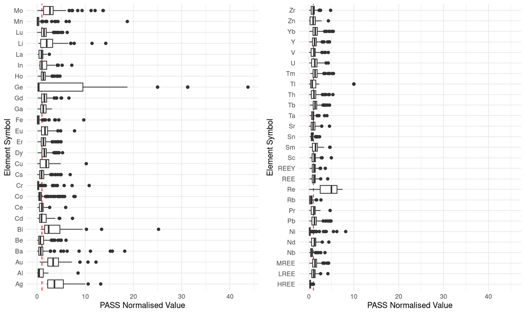

Figure 1.1: Distribution of Critical Elements (Box-Plot)

As depicted above, there are some key points that we would like to raise, which are:

  | Element Symbol | median |
  | --- | --- |
  | Re | 5.000 |
  | Ag | 3.600 |
  | Au | 3.333 |
  | Mo | 2.667 |
  | Bi | 2.402 |
  | Li | 2.000 |
  | Cu | 1.880 |
  | Eu | 1.648 |
  | Dy | 1.517 |
  | Gd | 1.513 |
  | Sm | 1.460 |
  | Lu | 1.438 |
  | Yb | 1.400 |
  | Tm | 1.364 |
  | Tb | 1.359 |
  | MREE | 1.344 |
  | Er | 1.320 |
  | Ho | 1.306 |
  | U | 1.304 |
  | Ga | 1.291 |
  | Y | 1.250 |
  | Pb | 1.235 |
  | Nd | 1.221 |
  | Sc | 1.191 |
  | REEY | 1.151 |
  | REE | 1.130 |
  | Th | 1.107 |
  | V | 1.103 |
  | Pr | 1.092 |
  | LREE | 1.064 |

## 1.4 Distribution of elements with reference to PASS levels

In this analysis, we are trying to assess all critical elements towards the PAAS standard. To begin with, we start from a high-level distribution across the two main categories that we use in identifying which elements that fall under above/below standard categories. The normalised value will be flagged as “Enriched above background” if it is above 1, while the rest will be flagged as “Below background”. The **Figure 1.2** provide the details about this high-level distribution.

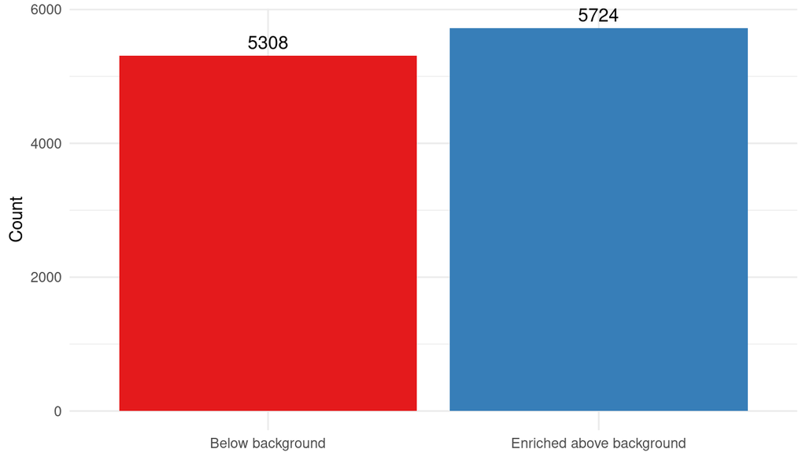

Figure 1.2: The Profile of PASS Categories

Moving on to the element’s level, we will assess how each critical element’s PAAS level, whether they are above/below background value. The Figure 1.3 shows the profile of each sample towards this standard and their respective flags.

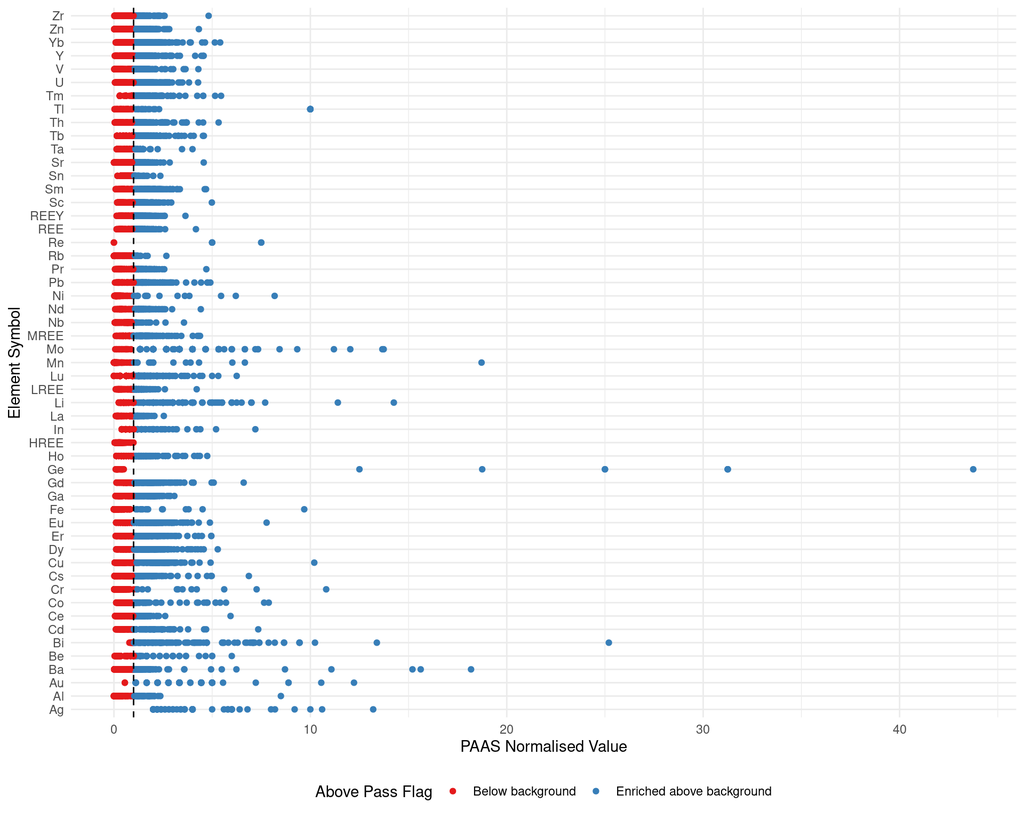

Figure 1.3: Distribution of elements with reference to PASS levels’ Concentration

As can be seen, the majority of normalised value fall within 0 to 10. Some highlight points from this plot are:

- **Ag** does not have any normalised PAAS values below background, indicating that coal waste is rich in **Ag**.
- **HREE** concentrations are always below background value.
- The significant differences in PAAS normalised value for some elements like **Ge** and **Re** needs further investigation as to why for a particular element that was sourced from coal and coal byproducts, such big gap could happen. In the later analysis, we will reveal if they are sampled from the same project area or they are actually sampled from different project area.
- All “below background” samples are actually just fall close to the threshold (between 0 and 1), indicating that coal and coal byproducts are highly potential as sources of these critical elements.

Furthermore, we also analyse how the distribution of the PAAS levels across various Project Area. The **Figure 1.4** shows how many elements that was recorded in each project area fall into two categories.

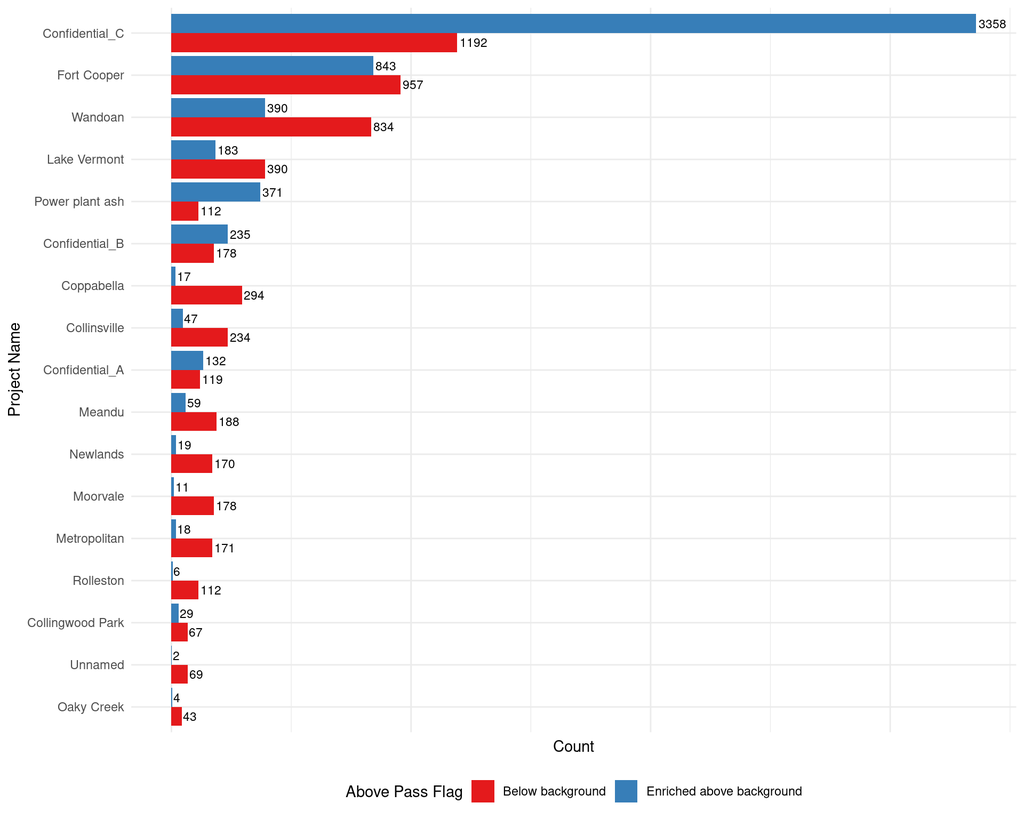

Figure 1.4: The Profile of Project Area with reference to PASS levels’ Concentration

Some key observations from the plot are:

- The **“Confidential_C”** project stands out with a substantial number of elements (3,358) categorised as **“Enriched Above Background”**, significantly outnumbering the **“Below Background”** category count (1,192). This suggests a considerable concentration of elements that exceeded PAAS standard in this project.
- Project such as **“Fort Cooper”**, **“Confidential_B”** and **“Confidential_A”** display a more balanced distribution between two categories, indicating a near-equal mix of elements that either meet or fall short of the enrichment criteria.
- In contrast, several projects, such as **“Wandoan”**, **“Copabella”**, **“Lake Vermont”**, **“Collinsville”**, **“Moorvalle”**, **“Newlands”**, **“Metropolitan”**, **“Rolleston”** exhibit a higher count of elements classified as **“Below Background”**. This implies that these projects have a significant proportion of elements that do not reach the enrichment threshold.
- A few projects, including **“Oaky Creek”**, and **“Unnamed”**, contribute minimally to the overall dataset, with very few elements categorised in either categories.

Lastly, let’s see how is the distribution of each critical element on every project area. The **Figure 1.5** below provide this information. As the continuation of the previous analysis, in this part we will focus more on the concentration of each element in each project area. For instance, such insights that we are going to look for are elements that have wide range of concentrations in one project, elements that have above/below background in the same project area.

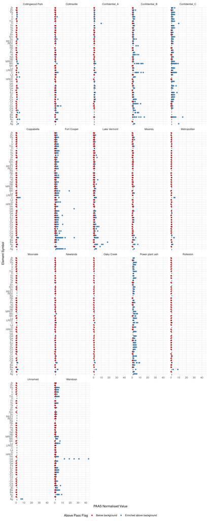

Figure 1.5: Distribution of Critical Elements by Each Project Area

As shown by above graphs, some significant insights are:

## 1.5 Correlation Matrix plot

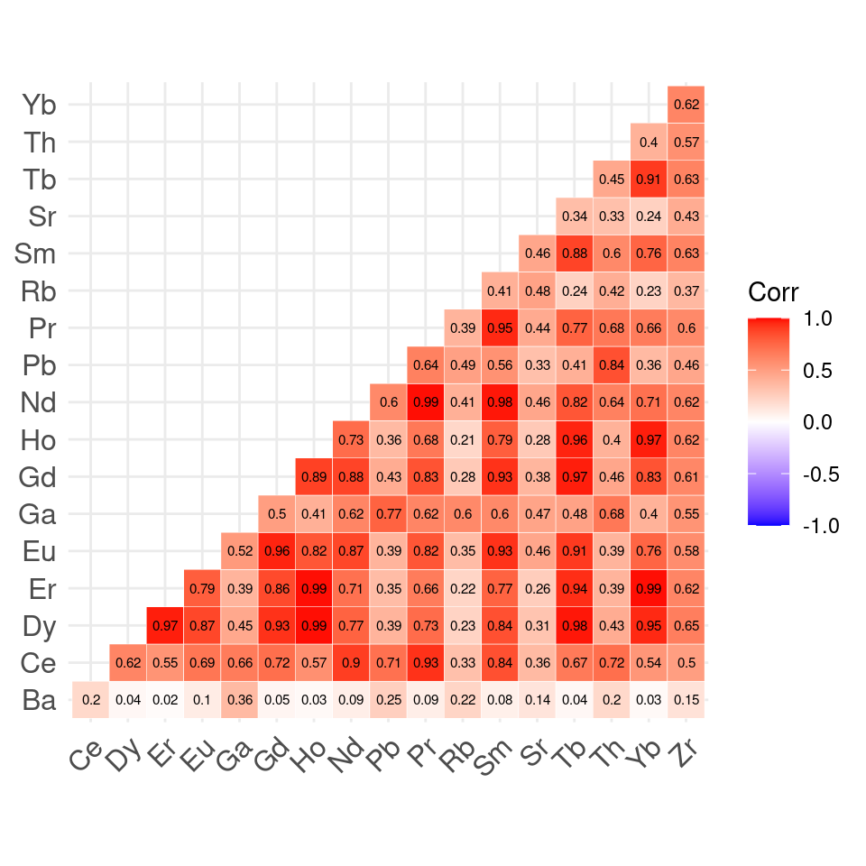

Figure 1.6: Correlation Matrix Plot of Critical Elements

The figure 1.6 shows the relationships between various elements. Some key observations are:

- Strongly positive correlations: There are numbers of elements that have very strong relationship (above 0.95), such as **Er**-**Dy**, **Gd**-**Eu**, **Ho**-**Dy**, **Ho**-**Er**, **Pr**-**Nd**, **Sm**-**Nd**, **Tb**-**Dy**, **Tb**-**Gd**, **Tb**-**Ho**, **Yb**-**Er**, and **Yb**-**Ho**. There are also many more elements that have correlation above 0.8.
- Moderate correlations: Many elements fall between 0.6-0.8, which indicate fairly strong relationships.
- Weaker Correlations: Elements such as **Ba** show weaker correlations with most other elements, indicating less consistent co-occurrence or independent behavior within the dataset.This also the case for **Sr**.

## 1.6 Scatter Plot

In this last section, we are going to dig deeper into critical elements that have correlation value above 0.95 (as mentioned in the previous points). For context, **Er**, **Dy**, **Gd**, **Eu**, **Ho**, **Pr**, **Nd**, **Sm**, **Tb**, and **Yb** are known as **lanthanides series**. Lanthanides are a group of the first 15 f-block elements with atomic numbers from 57 to 71. In addition to yttrium, which share many similar chemical properties with the lanthanides, these elements comprise the rare earth elements (REEs) (Mattocks et al., 2021). Their high correlation values are most likely affected due to this fact.

Furthermore, Seredin (2012) suggest that the first suggestions for recovering lanthanides and yttrium (REY) as by-products from coal deposits can be traced back to 20 years ago, following the discovery of coal beds in a Russian Far East (RFE) basin that had high REY content (0.2% - 0.3%). Additional coal seams with comparable or even higher REY concentrations (up to 1.0% in ash) were identified in six coal-bearing basins across the same region. Since then, REY-rich coal has also been discovered in coal basins in various other countries. Thus, the lanthanides are found in coal and coal by-products could be possible because of their association with the materials that make up coal.

**Correlated element (Above 0.95)**

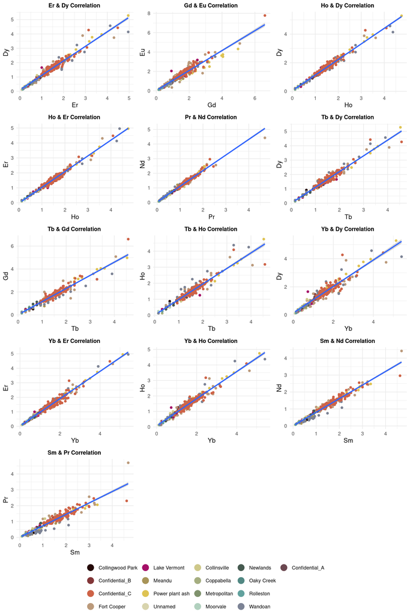

Figure 1.7: Strongly Correlated Critical Elements

The **Figure 1.7** above depicted show correlations between these elements, additional colour dimension was added to differentiate the project areas. In summary, there are many correlations that closely align to each other, as shown by the **tight spread of the dot points around the straight line**, which are exhibited by **Pr & Nd, Gd & Eu, Ho & Er, Tb & Dy, Yb & Er, Sm & Nd, and Sm & Pr plots**. In some of the plots, there are a few data points that **deviate from the majority of the points**. These could be potential outliers or cases where the relationship slightly diverges, which are exhibited by **Er & Dy, Ho & Dy, Yb & Dy, Yb & Ho, Tb & Ho, Tb & Gd plots**. For **Sm & Nd, and Sm & Pr plots** even though they are belong to the previous group, but when we look closely from the project area point of view, we can see that the grey dots (which represents ‘Wandoan’) are deviating away from the linear line. This indicates the correlation between them are not strong. Let’s dig deeper into these elements by utilising plots below.

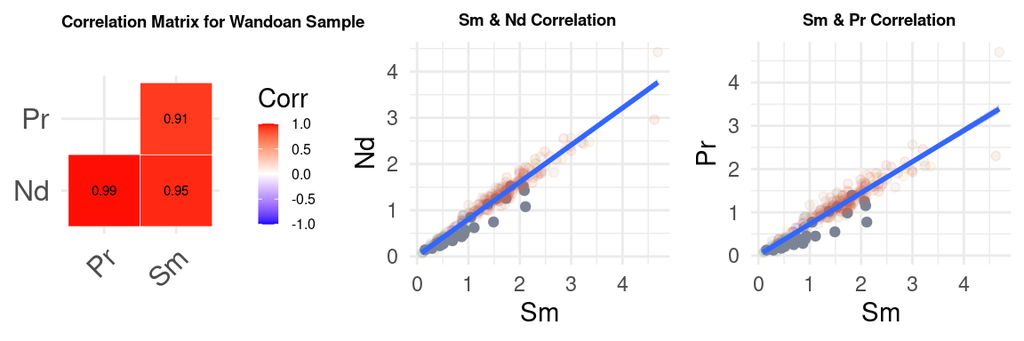

Figure 1.8: Correlated Critical Elements (Sm, Pr, Nd) in Wandoan

As can be seen in the correlation matrix of **figure 1.8**, in Wandoan, the correlation between **Sm** and **Nd** is 0.95, just right at the minimum threshold that we chose. However, **Sm** and **Pr** correlation is below 0.95, which contributes to the fact that the points deviate away from the linear line. Considering their correlation value is below our threshold, it’s most likely that **Sm** and **Pr** correlation from this project is excluded for the predictive modelling part.

# 2 Reference

- Mattocks, J. A., Tirsch, J. L., & Cotruvo, J. A., Jr (2021). Determination of affinities of lanthanide-binding proteins using chelator-buffered titrations. Methods in enzymology, 651, 23–61. https://doi.org/10.1016/bs.mie.2021.01.044
- Seredin, V. V., & Dai, S. F. (2012). Coal Deposits as Potential Alternative Sources for Lanthanides and Yttrium. International Journal of Coal Geology, 94, 67-93. https://doi.org/10.1016/j.coal.2011.11.001
- Wickham H, François R, Henry L, Müller K, Vaughan D (2023). *dplyr: A Grammar of Data Manipulation*. R package version 1.1.4, https://github.com/tidyverse/dplyr, https://dplyr.tidyverse.org.
- Wickham H, Averick M, Bryan J, Chang W, McGowan LD, François R, Grolemund G, Hayes A, Henry L, Hester J, Kuhn M, Pedersen TL, Miller E, Bache SM, Müller K, Ooms J, Robinson D, Seidel DP, Spinu V, Takahashi K, Vaughan D, Wilke C, Woo K, Yutani H (2019). “Welcome to the tidyverse.” *Journal of Open Source Software*, *4*(43), 1686. doi:10.21105/joss.01686 https://doi.org/10.21105/joss.01686.
- H. Wickham. ggplot2: Elegant Graphics for Data Analysis. Springer-Verlag New York, 2016.
- Xie Y (2024). *knitr: A General-Purpose Package for Dynamic Report Generation in R*. R package version 1.48, https://yihui.org/knitr/.
- Yihui Xie (2015) Dynamic Documents with R and knitr. 2nd edition. Chapman and Hall/CRC. ISBN 978-1498716963.
- Yihui Xie (2014) knitr: A Comprehensive Tool for Reproducible Research in R. In Victoria Stodden, Friedrich Leisch and Roger D. Peng, editors, Implementing Reproducible Computational Research. Chapman and Hall/CRC. ISBN 978-1466561595.
- Zhu H (2024). *kableExtra: Construct Complex Table with ‘kable’ and Pipe Syntax*. R package version 1.4.0, https://github.com/haozhu233/kableExtra, http://haozhu233.github.io/kableExtra/.
- Taiyun Wei and Viliam Simko (2024). R package ‘corrplot’: Visualization of a Correlation Matrix (Version 0.94). Available from https://github.com/taiyun/corrplot
- Kassambara A (2023). *ggcorrplot: Visualization of a Correlation Matrix using ‘ggplot2’*. R package version 0.1.4.1, http://www.sthda.com/english/wiki/ggcorrplot-visualization-of-a-correlation-matrix-using-ggplot2.
- Auguie B (2017). *gridExtra: Miscellaneous Functions for “Grid” Graphics*. R package version 2.3.
- Xie Y (2024). *bookdown: Authoring Books and Technical Documents with R Markdown*. R package version 0.40, https://github.com/rstudio/bookdown.
- Xie Y (2016). *bookdown: Authoring Books and Technical Documents with R Markdown*. Chapman and Hall/CRC, Boca Raton, Florida. ISBN 978-1138700109, https://bookdown.org/yihui/bookdown.
- Komsta L, Novomestky F (2022). *moments: Moments, Cumulants, Skewness, Kurtosis and Related Tests*. R package version 0.14.1, http://www.komsta.net/, https://www.r-project.org.